# Preparation of SNP genotypes in Nexus format

J. Ignacio Lucas Lledó

2026-03-05

For the purpose of Bayesian species delimitation, with SNAPPER (Stoltz et al. 2020), we need to prepare the input file, which should be a Nexus file with SNP genotypes. Actually, I advance that we have several options for generating a matrix of SNP genotypes, and I think it’s better to prepare more than one data set and run the same analysis on all them, to check for robustness.

## Calling genotypes with ANGSD

At least, we have two sets of BAM files: those aligned to the reference genome in `2023-05-18/BAM`, and those aligned to the set of ddRAD loci, in `2024-10-04/BAM`.

We already have selected variable sites with limited linkage disequilibrium and with a minimum number of 60 samples with at least 2 reads covering the site. And we have the genotype likelihoods of those sites in `../2024-03-11/Likes2/ARCTIC.beagle.gz`. However, for some reason, ANGSD does not do the job when provided with the list of sites and the genotype likelihoods. We have to feed it the raw BAM files and compute the likelihoods all over again. I will filter later.

The method implemented by Stoltz et al. (2020) is based on that of Bryant et al. (2012), where the authors explain very well how they compute the likelihoods. It turns out that the genotypes are turned to allele frequencies. The model assumes a Fisher-Wright population mating at random, but it does not model it explicitly. So, the important information in the data is not the distribution of genotypes, but the allele frequencies. Actually, the data file provided as an example suffers from a severe lack of heterozygotes. Thus, it is not essential to get accurate genotypes. SNAPPER would probably work equally well on haploids, or with a random sample of a single allele per site per individual. Thus, I should not be worried about some heterozygotes being called homozygous when coverage is low. I could use a low coverage threshold. But we do not need too many sites.

When calling genotypes another important argument is the posterior probability cutoff. If the three possible genotypes were equally probable, the posteriors would be 0.33, and a cutoff at that level would produce no missing data at all, but would introduce noise. I am willing to confound a heterozygote for any of the homozygotes (with equal probability). But I am not willing to confound the two homozygous genotypes. I will try with a cutoff of 0.75, and see how much missing data we get.

Another consideration is whether to use only variable sites or also the invariable ones. SNAPPER allows both. However, the interpretation of time units when using only variable sites is unclear: perhaps, expected number of mutations per site, knowing the site is variable? Such units are impossible to relate to estimates of mutation rate. In addition, once we get the most *a posteriori* probable genotypes, we may want to re-estimate nucleotide diversity measures, which require invariable sites.

Yet, another consideration is Hardy-Weinberg equilibrium. After having run the F$_{ST}$ analysis several times in folder `2024-10-10`, I realized several sites far from HWE seem to be collapsed paralogy, and I think it’s good to remove them. However, I am not separating individuals by population or putative species when calling genotypes. Thus, HWE does not apply.

```bash
SITES=../2024-03-11/Sites/ARCTIC_snp.sites
if [ ! -e GoodContigs.txt ]; then
   cut -f 1 $SITES | uniq | sed 's/$/:/' > GoodContigs.txt
fi

# Not excluding any individuals yet!
if [ ! -e bamlist1.txt ]; then
   ls -1 ../2023-05-18/BAM/*.bam > bamlist1.txt
fi
if [ ! -e toRef.geno ]; then
   if [ ! -e toRef.geno.gz ]; then
      angsd -bam bamlist1.txt \
            -ref ../2023-05-15/assembly.fasta \
            -out toRef \
            -baq 1 \
            -setMinDepthInd 4 \
            -minInd 80 \
            -GL 1 \
            -doMaf 2 \
            -doMajorMinor 1 \
            -doGeno 2 \
            -doPost 1 \
            -nThreads 8 \
            -postCutoff 0.75 1> toRef.log 2> toRef.err
   fi
   gunzip toRef.geno.gz
fi

if [ ! -e bamlist2.txt ]; then
   ls -1 ../2024-10-04/BAM/*.bam > bamlist2.txt
fi
if [ ! -e toRad.geno ]; then
   if [ ! -e toRad.geno.gz ]; then
      angsd -bam bamlist2.txt \
            -ref ../2024-10-03/consensus.fa \
            -out toRad \
            -baq 1 \
            -setMinDepthInd 4 \
            -minInd 80 \
            -GL 1 \
            -doMaf 2 \
            -doMajorMinor 1 \
            -doGeno 2 \
            -doPost 1 \
            -nThreads 8 \
            -postCutoff 0.75 1> toRad.log 2> toRad.err
   fi
   gunzip toRad.geno.gz
fi
```

## Filtering and preparing the input files for SNAPPER

### From alignments to reference

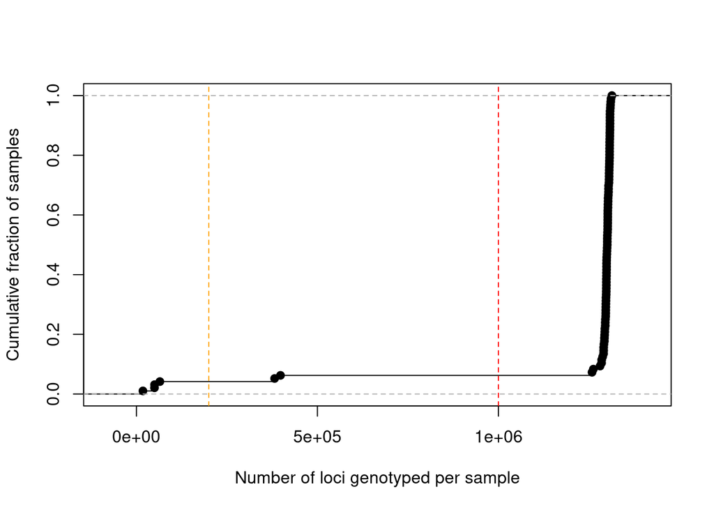

```r
toRef <- read.table('toRef.geno')
bams  <- scan('bamlist1.txt', what = 'character', quiet = TRUE)
samples <- sub('.bam', '', basename(bams))
rm(bams)
loci <- toRef[, 1:2]
names(loci) <- c('contig', 'pos')
geno <- toRef[, -c(1,2)]
names(geno) <- samples
plot(ecdf(colSums(geno >= 0)), xlab = 'Number of loci genotyped per sample',
     main = '', ylab = 'Cumulative fraction of samples')
abline(v = 200000, lty = 2, col = 'orange')
abline(v = 1000000, lty = 2, col = 'red')
```

I will include samples with at least 200000 genotyped loci, in order to include the two individuals which seem to belong to a different species, presumably *C. metoecus*, namely T165Cxa and S031Cmc. And for the moment, I will keep only variable sites genotyped in these samples.

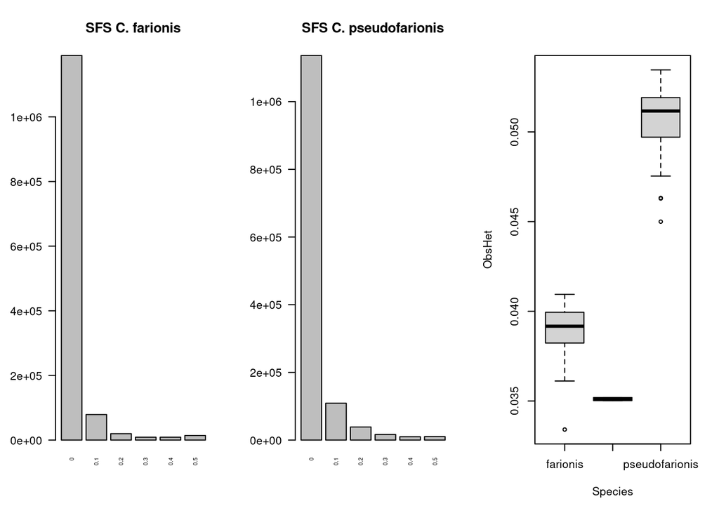

```r
MinLoci <- 200000
geno <- geno[, colSums(geno >= 0, na.rm = TRUE) > MinLoci]
#rm(toRef, samples)
geno[geno == -1] <- NA
GeneticIds <- read.table('../2024-10-05/summary.txt', header = TRUE)
GeneticIds$species <- ifelse(GeneticIds$K2.1 > 0.95, 'pseudofarionis', NA)
GeneticIds$species <- ifelse(GeneticIds$K2.2 > 0.95, 'farionis', GeneticIds$species)
Species <- GeneticIds[match(colnames(geno), GeneticIds$Sample), 'species']
Species[is.na(Species)] <- 'unknown'
Species[colnames(geno) %in% c('S031Cmc', 'T165Cxa')] <- 'metoecus'
f1 <- Species == 'farionis'
f2 <- Species == 'pseudofarionis'
f3 <- Species == 'metoecus'
loci$freqFario  <- rowSums(geno[,f1], na.rm = TRUE) /
   (2 * rowSums(geno[, f1] >= 0, na.rm = TRUE))
loci$freqFario <- ifelse(loci$freqFario <= 0.5, loci$freqFario, 1.0 - loci$freqFario)
loci$freqPseudo <- rowSums(geno[,f2], na.rm = TRUE) /
   (2 * rowSums(geno[, f2] >= 0, na.rm = TRUE))
loci$freqPseudo <- ifelse(loci$freqPseudo <= 0.5, loci$freqPseudo, 1.0 - loci$freqPseudo)
loci$freqMetoec <- rowSums(geno[,f3], na.rm = TRUE) /
   (2 * rowSums(geno[, f3] >= 0, na.rm = TRUE))
loci$freqMetoec <- ifelse(loci$freqMetoec <= 0.5, loci$freqMetoec, 1.0 - loci$freqMetoec)

# Remove unknown species from data set, which are admixed individuals
geno <- geno[, Species %in% c('farionis', 'pseudofarionis', 'metoecus')]
Species <- Species[Species %in% c('farionis', 'pseudofarionis', 'metoecus')]
ObsHet <- sapply(1:dim(geno)[2],
                 function(x) {
                    sum(geno[, x] == 1, na.rm = TRUE) / sum(! is.na(geno[, x]))
                 })

loci$freqs <- rowSums(geno, na.rm = TRUE) / (2 * rowSums(! is.na(geno)))
loci$freqs <- ifelse(loci$freqs <= 0.5, loci$freqs, 1.0 - loci$freqs)
par(mfrow = c(1,3))
barplot(table(round(loci$freqFario, 1)), las = 2, cex.names = 0.5, main = 'SFS C. farionis')
barplot(table(round(loci$freqPseudo, 1)), las = 2, cex.names = 0.5, main = 'SFS C. pseudofarionis')
boxplot(ObsHet ~ Species)
```

```r
withMetoecus <- ! (is.na(geno[, 'S031Cmc']) | is.na(geno[, 'T165Cxa']))
geno <- geno[withMetoecus, ]
loci <- loci[withMetoecus, ]
Variable <- loci$freqs > 0
genoVar <- geno[Variable, ]
lociVar <- loci[Variable, ]
```

```r
library(plyr)
MaxDist <- 1000
numloci <- dim(genoVar)[1]
lociVar$dist <- c(NA, lociVar[2:numloci, 'pos'] - lociVar[1:(numloci-1), 'pos'])
lastcontig <- c('contig_null', lociVar[1:(numloci - 1), 'contig'])
lociVar[lociVar$contig != lastcontig, 'dist'] <- NA
rm(lastcontig, numloci)
lociVar$locus <- cumsum(is.na(lociVar$dist) | lociVar$dist > MaxDist)
lociVar$n <- rowSums(! is.na(genoVar))
selected <- ddply(lociVar, .(locus), function(x) x[which.max(x$freqs * x$n),])
selIndex <- match(paste(selected$contig, selected$pos, ":"),
                  paste(lociVar$contig, lociVar$pos, ":"))
selGeno <- genoVar[selIndex,]
GenoStrings <- sapply(selGeno,
                      function(x) {
                         x[is.na(x)] <- '-'
                         paste0(x, collapse = '')
                      })
write('#NEXUS',
      file = 'toRef.nex')
write('BEGIN Data;',
      file = 'toRef.nex', append = TRUE)
write(sprintf('\tDIMENSIONS NTAX=%i NCHAR=%i;',
              length(GenoStrings), nchar(GenoStrings[1])),
      file = 'toRef.nex', append = TRUE)
write('\tFormat datatype=integerdata symbols="012" missing=-;',
      file = 'toRef.nex', append = TRUE)
write('\tMatrix',
      file = 'toRef.nex', append = TRUE)
write.table(data.frame(Sample = names(geno), Genotypes = GenoStrings),
            'toRef.nex', quote = FALSE, row.names = FALSE,
            col.names = FALSE, append = TRUE)
write('\t;',
      file = 'toRef.nex', append = TRUE)
write('END;',
      file = 'toRef.nex', append = TRUE)
```

## Creation of a small data set for testing

I originally thought that a toy dataset should contain just far fewer SNPs. Then, I learned that what actually reduces the speed of execution of SNAPPER is the reduction of the number of individuals per species. I will reduce both.

```r
toy <- selected[sample(1:dim(selected)[1], 1000),]
toyIndex <- match(paste(toy$contig, toy$pos, ":"),
                  paste(loci$contig, loci$pos, ":"))
metoecus <- c('T165Cxa', 'S031Cmc')
farionis <- colnames(geno)[Species == 'farionis']
pseudofa <- colnames(geno)[Species == 'pseudofarionis']
few <- sort(c(metoecus, sample(farionis, 10), sample(pseudofa, 10)))
toyGeno <- geno[toyIndex, few]
toyStrings <- sapply(toyGeno,
                      function(x) {
                         x[is.na(x)] <- '-'
                         paste0(x, collapse = '')
                      })
write('#NEXUS',
      file = 'toy.nex')
write('BEGIN Data;',
      file = 'toy.nex', append = TRUE)
write(sprintf('\tDIMENSIONS NTAX=%i NCHAR=%i;',
              length(toyStrings), nchar(toyStrings[1])),
      file = 'toy.nex', append = TRUE)
write('\tFormat datatype=integerdata symbols="012" missing=-;',
      file = 'toy.nex', append = TRUE)
write('\tMatrix',
      file = 'toy.nex', append = TRUE)
write.table(data.frame(Sample = few, Genotypes = toyStrings),
            'toy.nex', quote = FALSE, row.names = FALSE,
            col.names = FALSE, append = TRUE)
write('\t;',
      file = 'toy.nex', append = TRUE)
write('END;',
      file = 'toy.nex', append = TRUE)
```

## From alignments to ddRAD loci

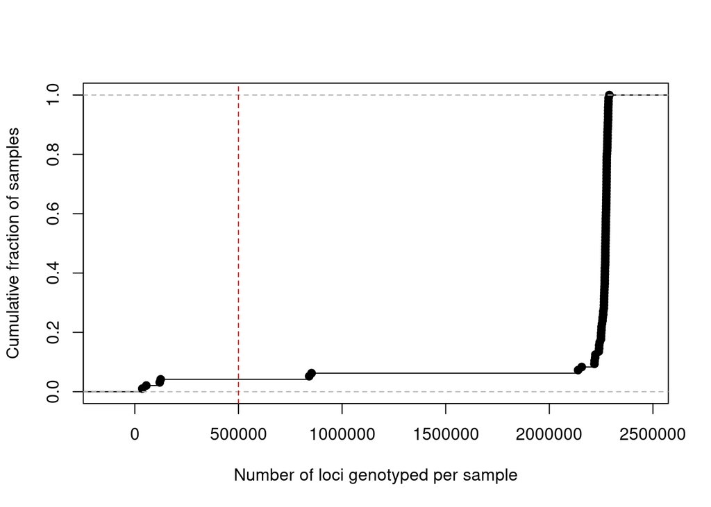

```r
rm(list=ls())
toRad <- read.table('toRad.geno')
bams  <- scan('bamlist2.txt', what = 'character', quiet = TRUE)
samples <- sub('.bam', '', basename(bams))
rm(bams)
loci <- toRad[, 1:2]
names(loci) <- c('contig', 'pos')
geno <- toRad[, -c(1,2)]
names(geno) <- samples
plot(ecdf(colSums(geno >= 0)), xlab = 'Number of loci genotyped per sample',
     main = '', ylab = 'Cumulative fraction of samples')
abline(v = 500000, lty = 2, col = 'red')
```

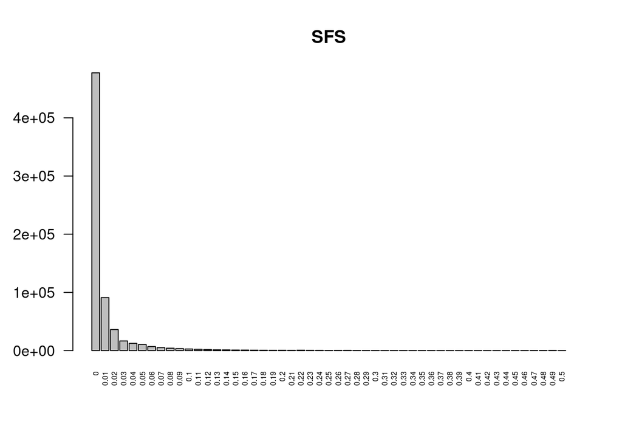

```r
MinLoci <- 500000
geno <- geno[, colSums(geno >= 0) > MinLoci]
rm(toRad, samples)
geno[geno == -1] <- NA
GeneticIds <- read.table('../2024-10-05/summary.txt', header = TRUE)
GeneticIds$species <- ifelse(GeneticIds$K2.1 > 0.95, 'pseudofarionis', NA)
GeneticIds$species <- ifelse(GeneticIds$K2.2 > 0.95, 'farionis', GeneticIds$species)
Species <- GeneticIds[match(colnames(geno), GeneticIds$Sample), 'species']
Species[is.na(Species)] <- 'unknown'
Species[colnames(geno) %in% c('S031Cmc', 'T165Cxa')] <- 'metoecus'
f1 <- Species == 'farionis'
f2 <- Species == 'pseudofarionis'
f3 <- Species == 'metoecus'
loci$freqFario  <- rowSums(geno[,f1], na.rm = TRUE) /
   (2 * rowSums(geno[, f1] >= 0, na.rm = TRUE))
loci$freqFario <- ifelse(loci$freqFario <= 0.5, loci$freqFario, 1.0 - loci$freqFario)
loci$freqPseudo <- rowSums(geno[,f2], na.rm = TRUE) /
   (2 * rowSums(geno[, f2] >= 0, na.rm = TRUE))
loci$freqPseudo <- ifelse(loci$freqPseudo <= 0.5, loci$freqPseudo, 1.0 - loci$freqPseudo)
loci$freqMetoec <- rowSums(geno[,f3], na.rm = TRUE) /
   (2 * rowSums(geno[, f3] >= 0, na.rm = TRUE))
loci$freqMetoec <- ifelse(loci$freqMetoec <= 0.5, loci$freqMetoec, 1.0 - loci$freqMetoec)
geno <- geno[, Species %in% c('farionis', 'pseudofarionis', 'metoecus')]
Species <- Species[Species %in% c('farionis', 'pseudofarionis', 'metoecus')]
ObsHet <- sapply(1:dim(geno)[2],
                 function(x) {
                    sum(geno[, x] == 1, na.rm = TRUE) / sum(! is.na(geno[, x]))
                 })

loci$freqs <- rowSums(geno, na.rm = TRUE) / (2 * rowSums(geno >= 0, na.rm = TRUE))
loci$freqs <- ifelse(loci$freqs <= 0.5, loci$freqs, 1.0 - loci$freqs)

withMetoecus <- ! (is.na(geno[, 'S031Cmc']) | is.na(geno[, 'T165Cxa']))
geno <- geno[withMetoecus, ]
loci <- loci[withMetoecus, ]
Variable <- loci$freqs > 0
genoVar <- geno[Variable, ]
lociVar <- loci[Variable, ]

barplot(table(round(loci$freqs, 2)), las = 2, cex.names = 0.5, main = 'SFS')
```

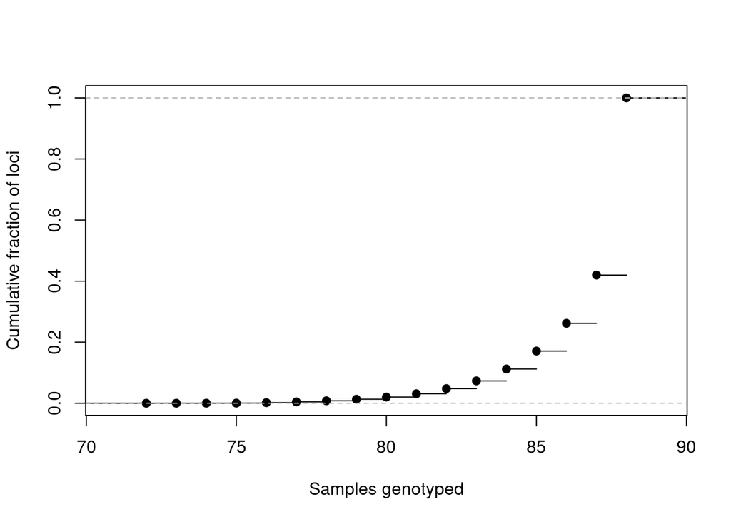

```r
loci$completeness <- rowSums(! is.na(geno))
plot(ecdf(loci$completeness), xlab = 'Samples genotyped',
     ylab = 'Cumulative fraction of loci', main = '')
```

I still need to remove positions in close linkage from others. The strategy here is to keep only one SNP per ddRAD locus: the one that maximizes the product of minor allele frequency and completeness.

```r
library(plyr)
MinCompleteness <- 80
MinFreq <- 0.25
#f <- loci$completeness >= MinCompleteness & loci$freqs >= MinFreq
f <- ! (is.na(geno[,'S031Cmc']) | is.na(geno[,'T165Cxa'])) & loci$freqs >= MinFreq
loci <- loci[f,]
geno <- geno[f,]

selected <- ddply(loci, .(contig), function(x) x[which.max(x$freqs * x$completeness),])
selIndex <- match(paste(selected$contig, selected$pos, ":"),
                  paste(loci$contig, loci$pos, ":"))
selGeno <- geno[selIndex,]
GenoStrings <- sapply(selGeno,
                      function(x) {
                         x[is.na(x)] <- '-'
                         paste0(x, collapse = '')
                      })
write('#NEXUS',
      file = 'toRad.nex')
write('BEGIN Data;',
      file = 'toRad.nex', append = TRUE)
write(sprintf('\tDIMENSIONS NTAX=%i NCHAR=%i;',
              length(GenoStrings), nchar(GenoStrings[1])),
      file = 'toRad.nex', append = TRUE)
write('\tFormat datatype=integerdata symbols="012" missing=-;',
      file = 'toRad.nex', append = TRUE)
write('\tMatrix',
      file = 'toRad.nex', append = TRUE)
write.table(data.frame(Sample = names(geno), Genotypes = GenoStrings),
            'toRad.nex', quote = FALSE, row.names = FALSE,
            col.names = FALSE, append = TRUE)
write('\t;',
      file = 'toRad.nex', append = TRUE)
write('END;',
      file = 'toRad.nex', append = TRUE)
```

# References

Bryant, D., R. Bouckaert, J. Felsenstein, N. A. Rosenberg, and A. RoyChoudhury. 2012. “Inferring Species Trees Directly from Biallelic Genetic Markers: Bypassing Gene Trees in a Full Coalescent Analysis.” *Molecular Biology and Evolution* 29 (8): 1917–32. https://doi.org/10.1093/molbev/mss086.

Stoltz, M., B. Baeumer, R. Bouckaert, C. Fox, G. Hiscott, and D. Bryant. 2020. “Bayesian Inference of Species Trees Using Diffusion Models.” *Systematic Biology* 70 (1): 145–61. https://doi.org/10.1093/sysbio/syaa051.